# Statistical Tests and Assumptions

siju.swamy@saintgits.org

October 27, 2018

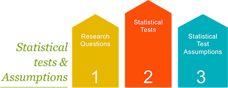

Agenda for the session

## Research questions and corresponding statistical tests

The most popular research questions include:

1. whether two variables (n = 2) are correlated (i.e., associated)

*Ans:* Correlation test between two variables

2. whether multiple variables (n > 2) are correlated

*Ans:* Correlation matrix between multiple variables

3. whether two groups (n = 2) of samples differ from each other

*Ans:* Comparing the means of two groups:

```
    -  Student's t-test (parametric)
    -  Wilcoxon rank test (non-parametric)
```

*Ans:* Comparing the means of more than two groups

```
- ANOVA test (analysis of variance, parametric): extension of t-test to compare more than two groups.
- Kruskal-Wallis rank sum test (non-parametric): extension of Wilcoxon rank test to compare more than two groups
```

## Tesing of variablility

5. whether the variability of two samples differ

*Ans:* Comparing the variances:

```
 - Comparing the variances of two groups: F-test (parametric)
 - Comparison of the variances of more than two groups: Bartlett's test (parametric), Levene's test (parametric)
 -and Fligner-Killeen test (non-parametric)
```

## Statistical test requirements

Many of the statistical procedures including correlation, regression, t-test, and analysis of variance assume some certain characteristic about the data. Generally they assume that:

- **the data are normally distributed,**
- **and the variances of the groups to be compared are homogeneous (equal)**

These assumptions should be taken seriously to draw reliable interpretation and conclusions of the research. These tests - correlation, t-test and ANOVA - are called parametric tests, because their validity depends on the distribution of the data.

## Pretest for statistical testing

- For large samples, parametric test can be used
- Use **Shapiro-Wilk’s** significance test comparing the sample distribution to a normal one in order to ascertain whether data show or not a serious deviation from normality

## A simple trick to attain normality!!

A statistically acceptable trick is to form a large ($n>100$) sample for analysis. The rest is with your statistical analysis tool.

## Normality Test in R

Normality and the other assumptions made by parametric tests should be taken seriously to draw reliable interpretation and conclusions of the research.

### Packages required

- *dplyr* for data manipulation
- *ggpubr* for an easy ggplot2-based data visualization

## Example

Choose the ToothGrowth data and test for normality:

```r
# Store the data in the variable my_data
my_data <- ToothGrowth
set.seed(1234)
dplyr::sample_n(my_data, 10)
```

```
##     len supp dose
## 7  11.2   VC  0.5
## 37  8.2   OJ  0.5
## 36 10.0   OJ  0.5
## 58 27.3   OJ  2.0
## 49 14.5   OJ  1.0
## 57 26.4   OJ  2.0
## 1   4.2   VC  0.5
## 13 15.2   VC  1.0
## 35 14.5   OJ  0.5
## 27 26.7   VC  2.0
```

For large sample these pretests are laxuaries.However, to be consistent, normality can be checked by visual inspection [normal plots (histogram), Q-Q plot (quantile-quantile plot)] or by significance tests].

## Normality test

*Approach*: Use a significance test comparing the sample distribution to a normal one in order to ascertain whether data show or not a serious deviation from normality.

There are several methods for normality test such as Kolmogorov-Smirnov (K-S) normality test and Shapiro-Wilk’s test. The null hypothesis of these tests is that “sample distribution is normal”. If the test is significant, the distribution is non-normal.

```r
shapiro.test(my_data$len)
```

```
##
##  Shapiro-Wilk normality test
##
## data:  my_data$len
## W = 0.96743, p-value = 0.1091
```

**Info**: From the output, the p-value > 0.05 implying that the distribution of the data are not significantly different from normal distribution. In other words, we can assume the normality.

## Visual methods

Density plot and Q-Q plot can be used to check normality visually.

### Density Plot

```r
library("ggpubr")
```

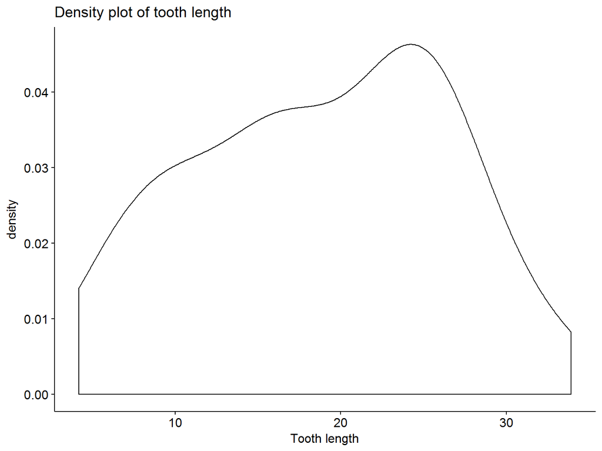

```r
ggdensity(my_data$len,
          main = "Density plot of tooth length",
          xlab = "Tooth length")
```

## Q-Q Plot

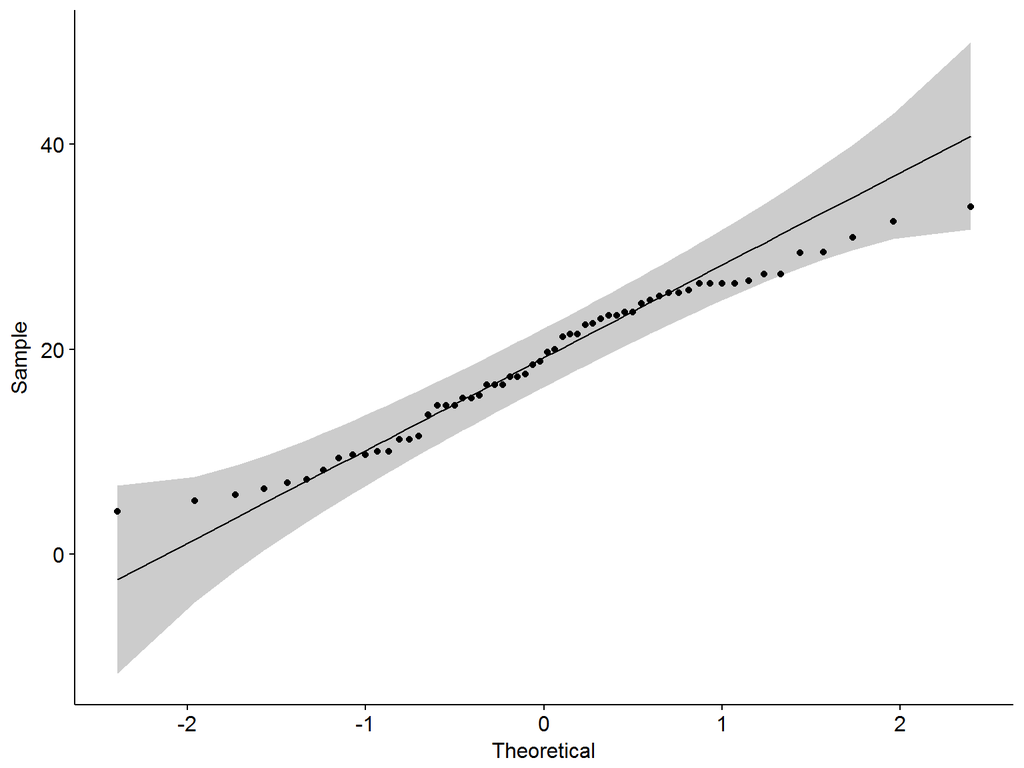

```r
ggqqplot(my_data$len)
```

## qqPlot()

It’s also possible to use the function qqPlot() [in car package]:

```r
library("car")
```

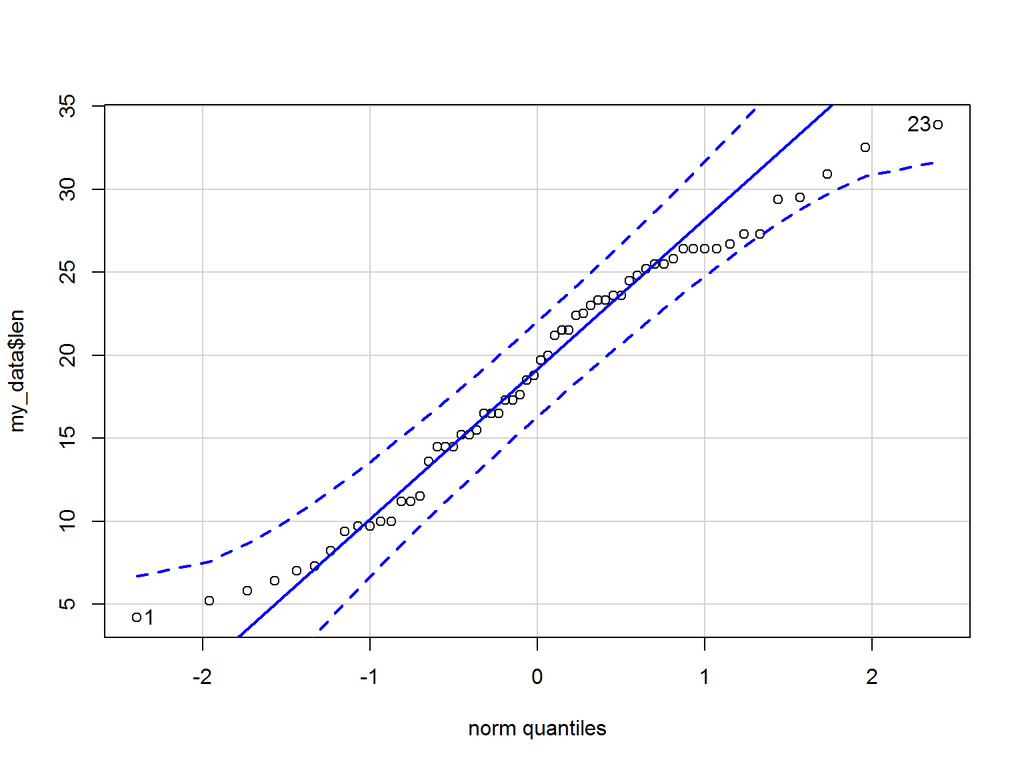

```
## [1] 23  1
```

```r
qqPlot(my_data$len)
```

## Takeaway from the session

-Always form good research questions and hypothesis for analysis.

- In case of parametric tests, always make sure that the group of data to be analyzed follows normal distribution.
- If normality can not be maintained, then try non- parametric tests.
- Always use large samples for statistical analysis.